# Digital Twin Technology

Math514: Contemporary Issues in Data Science

Phoebe Oliver, Alicia Le Cheminant, Dimitris Morris and David Grant

18-05-2022

# What is Digital Twin technology?

Digital twin is a digital representation of a physical object, process, or service. A digital twin could be a digital replica of a physical object, such as a jet engine or wind farms, or even much larger objects, such as buildings or whole cities. Alongside physical assets, digital twin can also be utilised to replicate processes to analyse and predict how they will perform under different conditions and can determine and monitor lifecycles.

Digital twins are created to allow a virtual computer model to collect feedback from sensors that collect data from the real-world version. This allows the digital version to imitate and simulate the operations of the original version. This is achieved by creating an interface between the digital model and an actual physical object to send and receive feedback and data in real time.

[video not shown]

### Why use it?

- Streamlined design
- Cost cutting
- Reduced time to market
- Predictive measures
- Improved customer experience

A digital twin can be used to save time and money whenever a product or process needs to be tested, whether in design, implementation, monitoring, or improvement.

Digital twins can significantly improve enterprises’ data-driven decision-making processes. They are linked to their real-world equivalents and businesses use digital twins to understand the state of the physical asset, respond to changes, improve operations, and add value to the systems.

# Types of Digital Twin

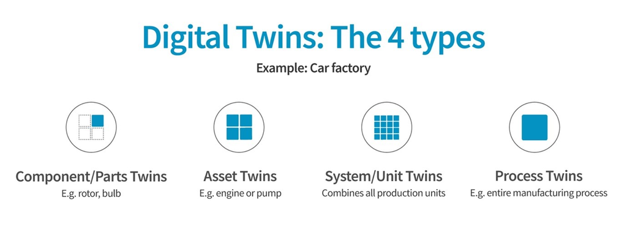

Digital Twin can be separated into four types:

Digital twin can also be broken down into three categories relating to the stage at which they are used:  
* **Digital Twin Prototype (DPT)** - This is undertaken before a physical product is created * **Digital Twin Instance (DTI)** - This is done once a product is manufactured in order to run tests on different usage scenarios * **Digital Twin Aggregate (DTA)** - This gathers DTI information to determine the capabilities of a product, run prognostics and test operating parameters

# Advantages and Diadvantages of Digital Twin Technology

The advantages and disadvantages of digital twins can be interpreted broadly, and within specific industries.

### Internet Connectivity

Digital Twins require internet connectivity to operate. This enables organisations to stream usage and performance data in real time (Al-Dhlan, 2021). This is practical for accessing and transferring information globally. However, any error limiting internet connectivity will limit the advantages of a digital twin.

### Prospect of Innovation

The prospect of innovation regarding digital twinning covers manufacturing, research and development, and supply chain management. Simulation of production processes can identify failures pre-emptively and reduce unplanned downtime by eliminating inefficiencies (Zhou et. Al, 2021). A by-product of this is reduced maintenance cost on labour and capital.

However, these designs, and the data of which they are founded upon, will evolve as the product evolves. This is inevitable, considering the advent of Industry 4.0, globalisation, and the inconstant variables of contemporary manufacturing (Al-Dhlan, 2021).

### Computer-aided Design

Computer-aided design (CAD) software provides tools for precise measurements required for effective digital twinning. The processes of CAD can be automated, and code can be re-used for similar structures, with internal boundaries set to avoid duplication (Arcvertex, 2022). As such, CAD has made digital twinning an effective logistical tool.

Nevertheless, designs can be lost from a breakdown in computer systems. Similarly, the nature to which CAD designs are established means that they are vulnerable to hacking. This may be an avoidable issue for large scale businesses, but smaller businesses may be further ostracised from digital twinning practises, concerning farther investment in cybersecurity (Ibid).

### Manufacturing

Digital twinning can be applied during both the manufacturing and the design process (Rathore et. Al, 2021). The ability to anticipate errors in design proactively can optimise manufacturing processes and minimise downtime. Despite this, as manufacturing processes change, so will the design of the digital twin. This calls for further retesting which may make earlier praise of ‘optimisation’ redundant.

### Automotive

In the automotive industry, the ability to prevent failures in the early stages of production can greatly improve the quality of the final vehicle (Bajaj and Seema, 2019). Again, this refers to the simulation of both manufacture and labour. As these simulations are repeated, the merit of the production process will only increase overtime.

### Logistics

Virtual tests can simulate the flows of both materials and labour (DHL, 2022). These virtual tests can provide real information to logisticians which can more greatly improve their decision-making. Moreover, these simulations can test new technologies and act as precautionary experiment for logistical error.

### Medicine

Digital twinning has aided the development of new drugs in the pharmaceutical industry. “Patient like me” comparisons enable medical professionals to make healthcare decisions on a digital replica, as opposed to the patient themselves. This enables patient specific treatment plans, with advantages of greater patient safety, reduced suffering to animals and equal treatment of patients relative to their race, gender etc (Bjornsson et. al, 2020).

Digital twins in medicine pose socio-ethical risks (Popa et. al, 2021). Digital twins may be based on models present in academic literature, leading to biases (Ibid). Likewise, changes in personal identity and responsibility surrounding health may occur as it is objectified via a digital replica. There may also be danger of imposing technology under the bargain of achieving ‘better health’ and providing distress to individuals without universal healthcare (Ibid).

# Overcoming the Disadvantages of Digital Twins

Socio-ethical risks are aided by socio-ethical practice. These can be proposed through regulatory bodies to ensure that insurance companies do not issue any decision on premiums based on the absence of digital twins.

The changing variables of manufacture and globalisation are not matters isolated within digital twinning. For an organisation to operate effectively, these variables must be managed regardless of whether their chains are mapped digitally. In essence, an organisation would therefore have to change their maps for digital twinning in line with their other behaviours when reacting to change.

# Applications of Digital Twin

Projects that benefit from Digital Twin include: * Physically large projects - Buildings, bridges and other complex structures are bound by strict rules of engineering.  
* Mechanically complex projects - Jet turbines, automobiles, and aircraft. Digital twins can help improve efficiency within complicated machinery and mammoth engines. * Power equipment - This includes both the mechanisms for generating power and transmitting it. * Manufacturing projects - Digital twins excel at helping streamline process efficiency, as you would find in industrial environments with co-functioning machine systems.

Therefore, specific industries have benefited from implementing Digital Twins such as: * Engineering (systems) * Automobile manufacturing * Aircraft production * Railcar design * Building construction * Manufacturing * Power utlities

# Real Life Industry Applications of Digital Twin

In 2020, the digital twin market was values at 3.1 billion USD with some analysts theorising a rise to an estimated 48.2 billion USD by at least 2026.

### NASA

The first major use case stemmed from NASA. In its 2012 Modelling, simulation, information technology & processing roadmap, it was highlighted how NASA could apply digital twins to their operations. For example, the digital twin of a vehicle could fly the actual future mission before its launch allowing for the studying of the mission’s parameters, determining effects of various anomalies and validate mitigation strategies for degradation and damages. Moreover, NASA could determine a flight plan that yielded the greatest probability of success prior to launch by using the digital twin. Continuing yielding benefits of the digital twin, NASA can keep updates of the flying twin’s health parameters due to the close mirror states between the flying and digital twins. Thus, if a potentially catastrophic fault, damage or need for modifications to the mitigation parameters, NASA and its mission managers can use the digital twin to diagnose anomalies and make informed decisions about mitigation strategies.

[figure not shown]

### Formula 1

In the sport and motor industry, Formula 1 team Mercedes AMG Petronas have demonstrated how using a digital twin of their F1 car has helped them win 8 Constructors Titles. Pairing with TIBCO, Mercedes had a challenging action-packed year facing COVID protocols, new regulations, and new circuits and noted how critical the team’s use of digital twins played in the role of optimising car performance in a highly competitive environment. With many parts of the car having an impact of the overall performance, the Mercedes team can develop a digital twin comprising of an extensive amount of data from both testing and actual races. From this, results from simulations can then be used to set up and configure the cars throughout the race weekend. This digital twin has been a crucial element in Mercedes performance, specifically when testing was limited to 3 days and in a new test circuit different from the previous year. Moreover, it has allowed Mercedes to utilise their digital twin to determine pivotal strategy-based decision in a split second, such as in the last leg of highly competitive battles in the last leg of the races.

### Aviation

Boeing’s use of a digital twin has changed how Boeing designs its airplanes, by replicating the physical airplane parts and simulating how they will perform over the lifecycle of the airframe. The lifecycle is created by combing data about the components in-service product lifecycle to create a virtual three-dimensional digital twin that can model the simulated lifecycle of the environment and conditions the airplane will encounter. By using this digital twin asset development model, Boeing has been able to achieve 40% improvement in first-time quality of the parts and systems used to manufacture their commercial and military aeroplanes.

### NPRA Bridge

Combining digital twin technology alongside the IoT sensors and asset intelligence to help deliver real-time insight into their bridge behaviour. Inspections from the human eye do not adequately assess the wear and tear of the bridge. But with the implementation of the digital twin technology, such stresses can be recognised before they result in damage to the structure. Click the link below to see it in action.

[video not shown]

# The Future of Digital Twin Technology

**“First we build the tools, then they build us.” ~ Marshall McLuhan**

At present, engineering processes and machinery are so complex in design that experimenting with different approaches poses a risk of failure or disruption to the company that is too costly in finance and time for the company to afford. Implementation of digital twinning in companies enables teams to analyse the performance of business processes or products under different conditions. With successful deployment, digital twins have the potential to drastically innovate organisations’ development processes, saving significant money and elevating efficiency.

### Potential Future Applications of Digital Twin

#### *Sustainability*

(Accenture and Dassault Systèmes, 2021) in their work of Designing Disruption: The Critical Role of Virtual Twins in Accelerating Sustainability, explore use cases from five industries: construction and cities, consumer packaged goods, transportation and mobility, life sciences and electrical and electronics in advancing the understanding of how virtual twins could help meet the world’s sustainability goals. The application of digital twinning to these five industries alone can is predicted to unlock more than 7.5Gt of C02e emissions reductions through 2030 and US$1.3 trillion of economic value.

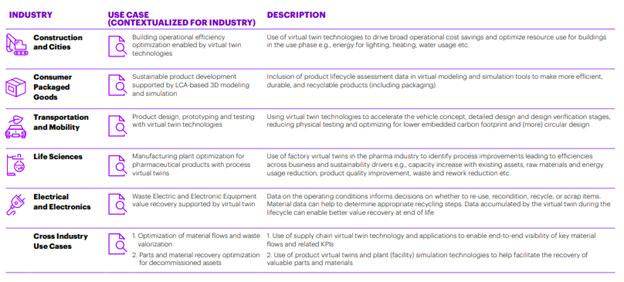

*1. Construction and Cities*  
Approximately a third of global green house gas (GHG) emissions are the result of commercial and residential buildings, accounting for 40 percent of global energy demand, 60% of the world’s electricity, and 25 percent of global water usage (Environmental Protection Agency, 2022). By integration of digital twin technologies within the broader framework of smart cities, consumption in buildings has the potential to be reduced by 30 to 80 percent.

*2. Consumer Packaged Goods*  
The consumer-packaged goods (CPG) industry currently accounts for two-thirds of international trade; agriculture, forestry and land use are responsible for almost a 25 percent of global GHG emissions and a staggering third of global food production is wasted across the value chain. With application of digital twins within the CPG industry, sustainable objectives can be applied at the start of the project lifecycle. Virtual prototyping allows for more cost effective testing in design alterations of consumer-package goods and manufacturing process driving significant CO2 benefits.

*3. Transporation and Mobility*  
Transport emissions account for 25 percent of global CO2 emissions in 2016 (Environmental Protection Agency, 2022) with this figure projected to drastically grow over time, challenging the decarbonization of the global economy. Research indicates zero-emission and autonomous vehicles to be key in achieving GHG reduction targets; digital twins allow manufacturers to test multiple designs and features in determination of design measures against policies and regulations. Furthermore, digital twins allow faster development of these zero-emission and autonomous vehicles that are so significant in our goal to reduce the global carbon footprint.

*4. Life Sciences*  
Life sciences are becoming increasingly pivotal in achieving our global goals of sustainability, however the industry itself is experiencing an increase in GHG emissions despite efforts of decarbonization as a result of increasing drug demand with the sector being approximately 55 percent more emissions intensive than the automotive industry.

Application of digital twin to this sector will allow scientists and researchers to digitalise the production process in running multiple scenarios with the objective of finding optimal configuration, speed acceleration and accuracy while reducing waste, including emissions.

*5. Electrical and Electronics*  
The electrical and electronics industry faces serious sustainability challenges; the manufacturing of equipment alone generates over a third of associated CO2e life cycle emissions. Successful deployment of digital twins can enable designers to follow circular economy principles throughout design and guide waste management in tackling the problem of e-wastage.

#### *Pharmaceuticals*

The deployment of digital twins in the pharmaceutical industry is still rudimentary, however data scientists have the vision to develop a high-yielding and versatile pharmaceutical manufacturing sector by adopting digital twin concepts and applying them to drug research and development, pharmaceutical supply chain management, and other manufacturing practices.

- Unlearn.AI recently received $50USD million Series B funding to advance the use of patient digital twins in clinical trials within cell therapy, where a patient’s modified cells are used for treatment. In this case, the information extracted from a patient is digitally collated and then channelled safely to the production equipment for analysis. For example, gene analysis is carried out to produce a personalized drug for the patient.
- In October 2021 (TwinHealth, 2021) secured a $140USD million Series C Funding to scale its ‘Whole Body Digital Twin’ service for chronic metabolic disease. Its Whole Body Digital Twin is a predictive digital tool, created using patient digital twins, to provide personalised nutrition, sleep and medicine through an application.
- The EU-funded Neurotwin Project (Neurotwin, 2021) aims to incorporate digital twins for developing personalised hybrid brain models in treatment of conditions such as epilepsy and Alzheimer’s of which recent findings suggest non-invasive electrical brain stimulation to be a potential treatment. It is the objective of the project to employ the personalised brain models to design and test personalised neuromodulation protocols capable of restoring healthy dynamics with a predicted end date of 31 December 2024.

### What’s next?

#### *Collaborating Twins*

Just as humans collaborate to innovate, so too will digital twins. A digital thread is responsible for much of the value associated with digital twins, this is the communication network that enables a connected flow of data and unifies diverse but interrelated datasets in order to uncover insight.

(MITSloan Management Review, 2020) use the example of a car ride. If you want to get from point A to B; however, you are siloed from every other driver, if every driver knew where everyone else needed to get to, travel time would become shorter for everyone. Connecting the digital twins of cars enables a fully autonomous car grid and innovation in mobility systems.

Furthermore, linking digital twins of completely different types of assets can feed the digital twin of more complex entities. An entire city, for example, could connect information from digital twins tied to weather patterns, pollution, citizens, traffic, transforming smart cities to conscious cities that are aware of assets flowing in and out of their borders.

#### *Corporate Innovation*

Similar to the promise of collaborating twins, the theory of corporate innovation pertains the idea that digital twins can connect all of an enterprise’s information, providing companies with a real-time holistic view of their operations, and allowing them to swiftly improve operating models, develop better strategies and discover new pockets of efficiency and, perhaps, finally eradicate silo mentality.

By adopting digital twins, companies can more effectively shift from the production and sale of a product to selling the use and maintenance of that product as a service. Consider Kaeser Kompressoren, a German company that used to sell air compressors. After introducing digital twins, it has moved toward selling air-as-a-service, where the customer only pays for their use of the compressor.

#### *Multiplier Effect*

The emergence and development of digital twins is coming at a time of particular scientific and technological development with many other new technologies finding their footing as well. Digital twins will combine with other emerging technologies to multiply their potential for innovation.